# MAPS Minors Historical Data

Jason Preszler

June 8, 2018

The purpose of this document is to investigate historical trends of minors within the MAPS department and see if there are relationships with certain majors. We focus on *Graduation Years* 2011-2017, and it should be noted that the graduation year is often one year earlier than their “class year” since, for example, a graduation year of 2017 includes students receiving degrees in Summer or Fall of 2017 and Spring of 2018.

The following table gives the minor codes (used by the registrar and institutional research), names, and peaks satisfied for each minor. Throughout this document we will primarily use the codes to refer to each minor.

| code | name | peak |
| --- | --- | --- |
| CSC | Computer Science | PSE |
| CSD | Computer Studies | NSM |
| DUENG | Dual-Degree Engineering | NSM and PSE |
| GEOSC | Geoscience | NSM |
| MAT | Mathematics | NSM |
| MATAP | Applied Math. | NSM |
| PHSCI | Physical Science | NSM |
| PHY | Physics | NSM |

If this seems like a long list, you’re right. The current catalog (2017-2018) lists 15 NSM minors, half of which are associated to the MAPS department (though MAPS is a bit of a hodge-podge department including Math, Computer Science, Physics, and Geology/Environmental Science faculty). Other peaks have similar numbers of minors - 16 in HFA (4 or which can count as SSH), 14 in SSH (again 4 are duplicated), and 18 in PSE.

## Data Acquisition and Preparation

The data was provided by the Registrar and Director of Institutional Research. It includes all students with graduation year 2011 or later who minored in at least one of the above MAPS minors. The original dataset included some students from earlier, pre-PEAK, years who have been removed. Identifying information including name and ID number have been removed, as have additional variables of graduation date, graduation term, and “Academic Level” which was *UG* for all students. A generic ID was added to to connect the multiple minors and majors together (as a single student) when reshaping data but this has no connection to the student ID. Leading and trailing white-space from all non-numeric variables was also removed which was necessary since some minor codes has leading spaces during earlier years.

## Overview of Data

The data shows that the 101 students received 44 different minors and 21 different majors. Of these students, 40 received a *BS* while the remaining 61 received a *BA*.

## Minor Counts over Time

First we look at the overall count of students received any MAPS minor, then we see how those counts are spread over time.

| minor | count |
| --- | --- |
| CSC | 23 |
| CSD | 12 |
| DUENG | 11 |
| MAT | 27 |
| MATAP | 15 |
| PHSCI | 10 |
| PHY | 9 |

|  | 2011 | 2012 | 2013 | 2014 | 2015 | 2016 | 2017 |
| --- | --- | --- | --- | --- | --- | --- | --- |
| CSC | 0 | 1 | 3 | 4 | 4 | 5 | 6 |
| CSD | 0 | 0 | 0 | 2 | 3 | 4 | 3 |
| DUENG | 0 | 1 | 0 | 1 | 2 | 2 | 5 |
| MAT | 2 | 4 | 4 | 9 | 6 | 2 | 0 |
| MATAP | 0 | 0 | 0 | 0 | 3 | 5 | 7 |
| PHSCI | 0 | 0 | 0 | 1 | 3 | 5 | 1 |
| PHY | 1 | 3 | 1 | 1 | 3 | 0 | 0 |

Notice that *Geosciences* isn’t listed since no students have graduated with this minor yet.

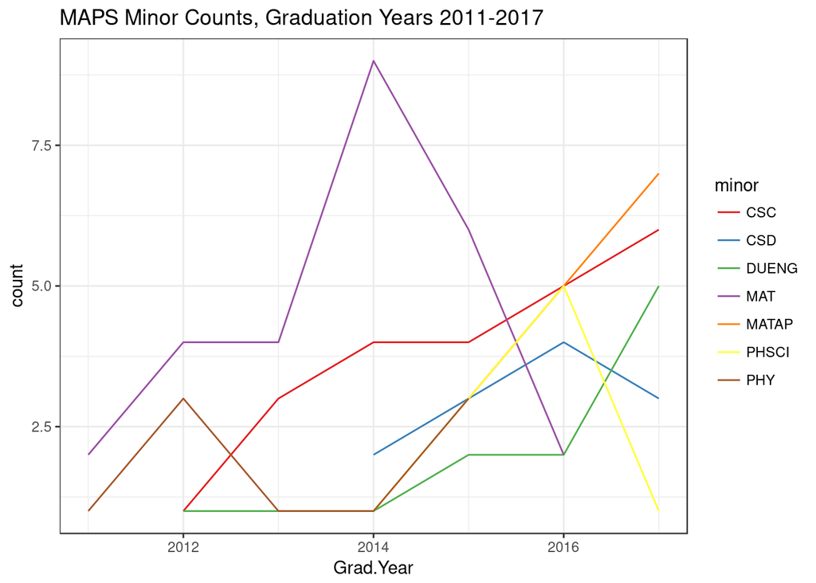

## Minor Combinations

The next table shows the count of students receiving minors outside MAPS for each of the MAPS minors that they earn. Only minor combinations with more than 2 students are listed.

| maps_minor | minor | count |
| --- | --- | --- |
| CSC | PSY | 8 |
| CSC | ARTDE | 5 |
| CSC | SPA | 3 |
| CSD | ARTDE | 4 |
| MAT | PSY | 6 |
| MAT | ARTDE | 4 |
| MAT | BUS | 4 |
| MAT | AIS | 3 |
| MATAP | PSY | 8 |
| PHY | ED10 | 3 |
| PHSCI | PSY | 3 |
| DUENG | PSY | 6 |

## Major-Minor Associations

Only 6 students have a second major, so we ignore these majors for this report (this may be worth looking into in the near future though). Below we have a table of the minors in MAPS and majors with more than 3 students earning that major/minor combination.

| minor | major | count |
| --- | --- | --- |
| CSC | MATPH | 13 |
| MATAP | BUS | 9 |
| CSD | BUS | 8 |
| DUENG | MATPH | 8 |
| MAT | BUS | 8 |
| MAT | POE | 4 |
| MAT | PSY | 4 |
| PHY | MAT | 4 |

The students minoring in Dual-Degree Engineering are *encouraged* to major or mathematics or math/physics and must be accepted to an approved engineering program, hence the high incidence of math/physics majors. As expected, there are also many students majoring in MAPS or Chemistry and using the CSC minor to satisfy the PSE PEAK. Besides these relationships within NSM, the most common majors earning minors within MAPS are business, psychology, and POE which are three of the most popular non-NSM majors at the College of Idaho.